# Second Markdown Assignment

### **The Monty Hall Problem**

#### Briefly discuss the Monty Hall problem and share your insights and solution to this brain teaser problem.

The **Monty Hall problem** is a probability puzzle named after the late Monty Hall, the original host of the TV show Let’s Make a Deal. In this problem, there are *3 doors*. Behind 1 door is *a car*; the grand prize that the contestant can win, while behind the other 2 doors contain *goats*. The contestant chooses a door at random which he or she believes is the door that contains the grand prize. The game host then opens one of the 2 remaining doors which reveals one of the goats inside. Now the contestant has the option to stick with his or her chosen door or switch to the other or remaining door to win the prize. The majority of people assume that both doors have the same probability to win, where the door you chose and the door that was left unopened have a 50/50 chance. Because there is no perceived reason to change, most stick with their initial choice. However, in terms of chances, that is not the case.

[figure not shown]

Monty Hall Problem

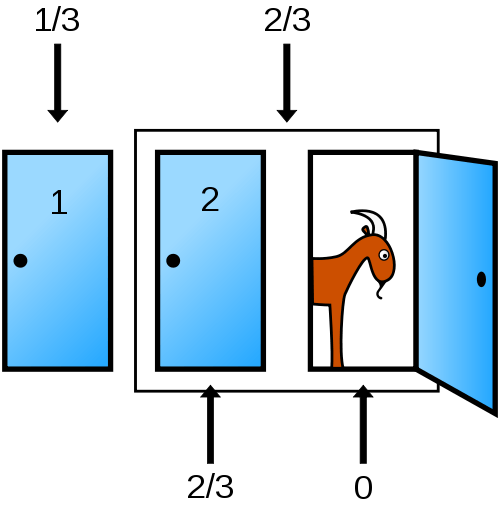

Monty Hall Problem Probability rates

To better understand the concept of probability in this game, let us look into the answer of columnist Marilyn vos Savant in her magazine Parade when she was asked about the same problem. According to her, there is about 66% chance (roughly ⅔) of winning the prize by switching (Frost, 2021). This is because there are only nine different combinations of choices and outcomes. Let us refer to this table:

```
##    row1 row2               row3               row4
## 1     1    1                Win               Lose
## 2     1    2               Lose                Win
## 3     1    3               Lose                Win
## 4     2    1               Lose                Win
## 5     2    2                Win               Lose
## 6     2    3               Lose                Win
## 7     3    1               Lose                Win
## 8     3    2               Lose                Win
## 9     3    3                Win               Lose
## 10           3 Wins (About 33%) 6 Wins (About 66%)
```

| Contestant’s initial door | Door with prize | Don’t Switch | Switch |
| --- | --- | --- | --- |
| 1 | 1 | Win | Lose |
| 1 | 2 | Lose | Win |
| 1 | 3 | Lose | Win |
| 2 | 1 | Lose | Win |
| 2 | 2 | Win | Lose |
| 2 | 3 | Lose | Win |
| 3 | 1 | Lose | Win |
| 3 | 2 | Lose | Win |
| 3 | 3 | Win | Lose |
|  |  | 3 Wins (About 33%) | 6 Wins (About 66%) |

The first column contains the numbers 1, 2 and 3 which represent each of the doors or labels each door. Meanwhile, the second column represents the door that has the prize. The third and fourth column tells whether the contestant wins or loses the game if he or she either sticks with his or her first choice or switches to the other door respectively. By enumerating these nine different combinations of choices and outcomes, we now have different potential situations where we could analyze the probability of winning between switching and not switching the contestant’s first choice. In the third column which represents the outcome if the contestant didn’t switch, most of the result would indicate that the contestant would have a 33% chance of winning if he or she sticks with his or her first choice; having a total of 3 wins and 6 losses considering all 9 scenarios. Meanwhile, if the contestant switches his or her door for the other unopened door, then he or she would have a bigger chance to win; having a total of 6 wins and 3 losses considering all 9 scenarios, which gives him or her a 66% chance of winning. If we compare the probabilities of winning between switching and not switching the door, then from the probability percentages we could conclude that the contestant would usually have a better chance of winning the prize if he or she switches his or her choice.

Here is the solution for solving the probability of winning the prize by switching:

Let P(A) be the Probability of getting a goat Let P(B|A) be the Probability of guessing correctly after switching Let P(A *intersection* B) be the Probability of getting the prize or winning by switching

**Names: Justine Sison and Sun Phil Zablan**

**References**

Frost, J. (2021, February 01). The monty hall problem: A statistical illusion. Retrieved July 15, 2021, from https://statisticsbyjim.com/fun/monty-hall-problem/

Statistics How to (2021, June 13). Monty Hall problem: Solution explained simply. Retrieved July 15, 2021, from https://www.statisticshowto.com/probability-and-statistics/monty-hall-problem/

### **The PSCO Lottery**

#### One of the most popular major games of PCSO is the Ultra Lotto 6/58. At ₱20 per ticket, how much would a bettor spend to cover all of the possible combinations. Would the grand prize of ₱50 million cover all the expenses or it would simply incur a massive loss on the bettor?

[figure not shown]

PCSO Logo

The Philippine Charity Sweepstakes Office (or PCSO for short) runs a variation of the lottery with 6 numbers, all from one to fifty-eight. The rules of the PCSO are simple, if the set of numbers picked by the host matches the numbers on your ticket, you win a prize pool of money! Take note the more winners there are, the more your prize pool is split.

This sounds like a lucrative to make money because of the massive prize pool and possible profit you gain from a single ticket, which costs 20 ₱. But with the lotto being the lotto, the odds are guaranteed to be stacked against everyone who participates, including you. So in this problem, we will find out just how much money it will take to have a 100% chance of finding the lucky number.

A few important points about the PCSO lotto if you have never played it before:

1. Six number balls will be picked from 1 – 58 through a vacuum system, assuring unpredictability
2. Once a ball is taken out, it is removed from the pool of possible numbers
3. The order of the numbers do not matter

This formula will help us find the total number of tickets we need to buy to guarantee a chance at winning the lottery. Inserting our known values into the formula gives us

$$40, 475, 358*20₱ = 809,507,160₱$$

Now that is a ton of money. With the theoretical grand prize being 50,000,000₱, let us see how much we will gain by buying that many tickets for that amount of money.

$$50,000,000₱ - 809,507,160₱ = -759,507,160₱$$
Now I do not know about you, but this feels like a net loss of astronomical scale.

In conclusion, spending enough money to have a 100% chance of winning the lottery would incur a financial loss on the bettor, one they would never be able to recover from, even if they win the lottery three times over.

The sheer amount of possible numbers in the lottery and the millions of bettors ensure its continued activities, meaning the ones running it will always make sure the odds are stacked against each individual bettor. In the off-chance that you do win the lottery, just know that you pulled of something that only happens to one in over forty million possibilities.

**Names: Lester Salvador and Jose Xavier Castillo**

**Reference**

## https://www.youtube.com/watch?v=nFz1UX-bZmA